# R Programming

## because…

> *"Data sets contain more information than they display."*

- Garrett Grolemund

## Key Things to Remember

## What to Remember from this Section

`dplyr` is a package that transforms and manipulates data

`select()`: select variables of concern

`filter()`: filter values based on conditions

`group_by()`: group data by categorical levels

`summarise()`: change unit of analysis

`arrange()`: order the data

## What to Remember from this Section

`dplyr` is a package that transforms and manipulates data

`mutate()`: create new variables

`join()`: combine separate data sets

## GR&A

### That means grounds rules & assumptions

## R package used…

install.packages("dplyr")

library(dplyr)

## data used…

install.packages("EDAWR")

library(EDAWR)

Data sets: storms, tb, pollution, iris, a, b

## %>% operator…

### learn it, love it, leverage it

- [magrittr](https://cran.r-project.org/web/packages/magrittr/index.html) → [Stefan Milton Bache](https://twitter.com/stefanbache)
- not required but extremely convenient

filter(data, variable == *numeric_value*)

*or*

data %>% filter(variable == *numeric_value*)

## %>% operator…

### learn it, love it, leverage it

```r
arrange(
        summarize(
                filter(data, variable == "numeric_value"),
                Total = sum(variable)
        ),
        desc(Total)
)
```

```r
a <- filter(data, variable == "numeric_value")
b <- summarise(a, Total = sum(variable))
c <- arrange(b, desc(Total))
```

```r
data %>%
        filter(variable == "value") %>%
        summarise(Total = sum(variable)) %>%
        arrange(desc(Total))
```

*Same results but the %>% operator is more efficient and legible*

## select( )

### Select variables of concern

## select( )

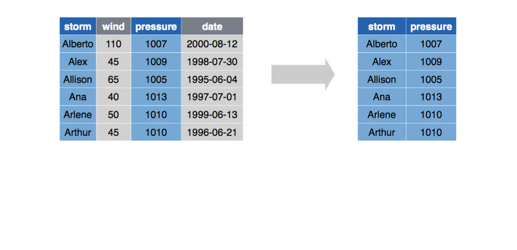

## select( )

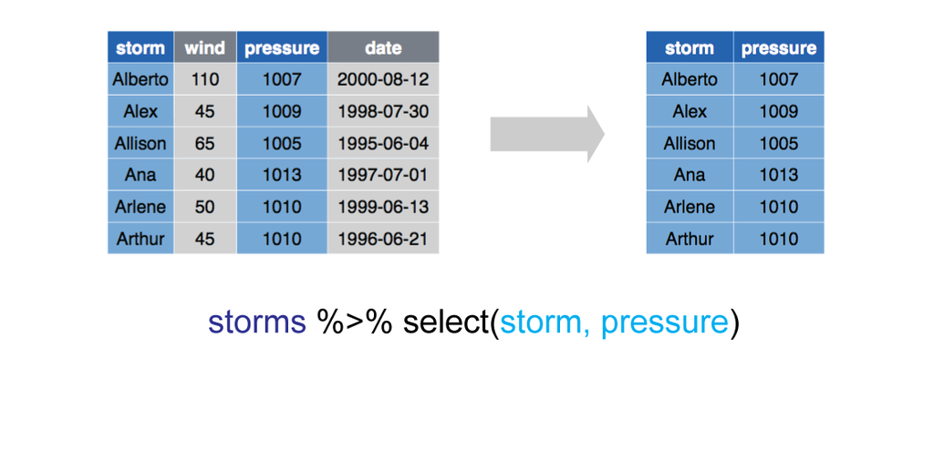